# EDA for Chune Enterprise

## Dealing with missing data

- MCAR (missing completely at random) values randomly missing not dependent on other values
- MAR (missinng at random) dependent on some other additional features
- MNAR (missing not at random) there is a reason why these values are missing

There are several methods of imputing missing data incluing the measures of central tendecies, regression imputation, and multiple imputation. Measure of central tendency involves replacing missing values with either Mean, Median, and Mode of the values. Regression imputation involves using other variables in the data set to predict missing values

- Mode can replace missing values for categorical data
- Mean or Median for numerical depending on if you have outliers or not
- Regression method is to predict the missing data. It is more advanced

```python
#Print the bottom rows using '.tail()' by default will show the last five rows. but you can put any number in the open bracket

df.tail()
```

|  | Date | Customer | Sales Person | Customer_Age | Customer_Gender | State | Product_Category | Sub_Category | Payment Option | Quantity | Unit_Cost | Unit_Price |
| --- | --- | --- | --- | --- | --- | --- | --- | --- | --- | --- | --- | --- |
| 34862 | 7-Feb-16 | High | Kenny | 38 | M | Ebonyi | Phones | IPhone | Online | 2.0 | 1160.0 | 985.50 |
| 34863 | 13-Mar-15 | High | Kenny | 38 | M | Ebonyi | Phones | IPhone | Online | 1.0 | 2049.0 | 1583.00 |
| 34864 | 5-Apr-15 | High | Kenny | 38 | M | Ebonyi | Phones | IPhone | Online | 3.0 | 683.0 | 560.67 |
| 34865 | 30-Aug-15 | High | Kenny | 38 | M | Ebonyi | Phones | IPhone | Online | 1.0 | 2320.0 | 1568.00 |
| 34866 | NaN | NaN | NaN | 38 | NaN | NaN | NaN | NaN | NaN | NaN | NaN | NaN |

```python
# Investigate the missing data
# creat a variable called null_vals
# using the [.isnull().sum] attached to your table that is "df"
# [.sum] will sum up all missing variables in the columns
null_val = df.isnull().sum()
null_val # it shows that all the columns have a missing variable except age
```

```
Date                1
Customer            1
Sales Person        1
Customer_Age        0
Customer_Gender     1
State               1
Product_Category    1
Sub_Category        1
Payment Option      1
Quantity            1
Unit_Cost           1
Unit_Price          1
dtype: int64
```

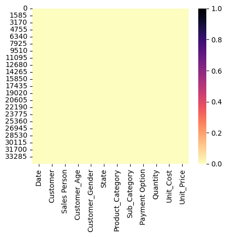

```python
## How to visualise the mssing data using
# matplotlib.pyplot as plt #data visualisation
#
plt.figure(figsize = (5,4)) # matplotlib.pyplot as plt the (5,4)) is just the size of the map
sns.heatmap(df.isnull(), cbar = True, cmap = "magma_r"); #seaborn as sns #heatmap, cbar: chart, cmap: colour of map #note the ;
```

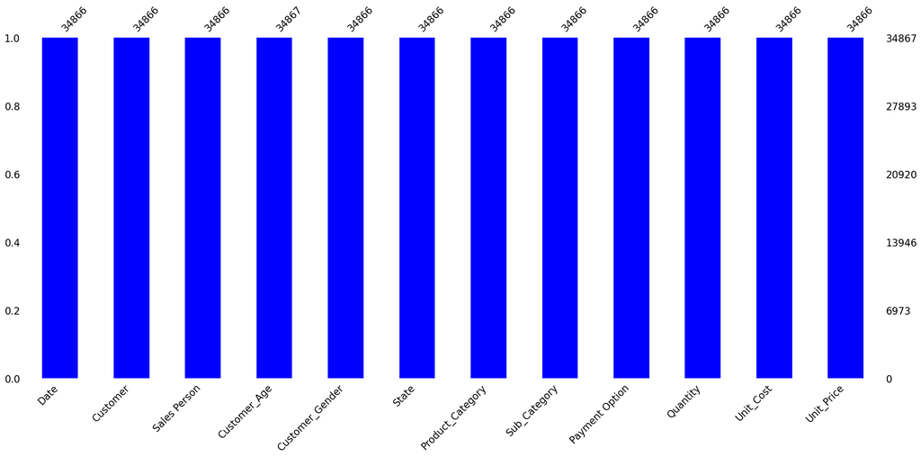

```python
#using "missingno" to visualise missing data like we did with matplotlib.pyplot as plt #data visualisation

msno.bar(df, color = 'blue');
```

```python
## where is the missing data on the df
# display the part with missing data
df.isnull() #this shows the row with the missing value as "TRUE"
```

|  | Date | Customer | Sales Person | Customer_Age | Customer_Gender | State | Product_Category | Sub_Category | Payment Option | Quantity | Unit_Cost | Unit_Price |
| --- | --- | --- | --- | --- | --- | --- | --- | --- | --- | --- | --- | --- |
| 0 | False | False | False | False | False | False | False | False | False | False | False | False |
| 1 | False | False | False | False | False | False | False | False | False | False | False | False |
| 2 | False | False | False | False | False | False | False | False | False | False | False | False |
| 3 | False | False | False | False | False | False | False | False | False | False | False | False |
| 4 | False | False | False | False | False | False | False | False | False | False | False | False |
| ... | ... | ... | ... | ... | ... | ... | ... | ... | ... | ... | ... | ... |
| 34862 | False | False | False | False | False | False | False | False | False | False | False | False |
| 34863 | False | False | False | False | False | False | False | False | False | False | False | False |
| 34864 | False | False | False | False | False | False | False | False | False | False | False | False |
| 34865 | False | False | False | False | False | False | False | False | False | False | False | False |
| 34866 | True | True | True | False | True | True | True | True | True | True | True | True |

34867 rows × 12 columns

```python
# to visulaise the exact row with the missing value
# ".any(axis=1)" will display the row woth the tRUE value showed in the previous data

df[df.isnull().any(axis=1)] #i can remove this row because it will not affect my analysis
```

|  | Date | Customer | Sales Person | Customer_Age | Customer_Gender | State | Product_Category | Sub_Category | Payment Option | Quantity | Unit_Cost | Unit_Price |
| --- | --- | --- | --- | --- | --- | --- | --- | --- | --- | --- | --- | --- |
| 34866 | NaN | NaN | NaN | 38 | NaN | NaN | NaN | NaN | NaN | NaN | NaN | NaN |

```python
# to drop the row from the data set

df.dropna(inplace=True)
```

```python
df.isnull().sum() # now no more missing values
```

```
Date                0
Customer            0
Sales Person        0
Customer_Age        0
Customer_Gender     0
State               0
Product_Category    0
Sub_Category        0
Payment Option      0
Quantity            0
Unit_Cost           0
Unit_Price          0
dtype: int64
```

```python
## Date time analysis
# it shows your data with date, like year, month, week, days, quarter etc

df.head(2) # to see the first two rows
```

|  | Date | Customer | Sales Person | Customer_Age | Customer_Gender | State | Product_Category | Sub_Category | Payment Option | Quantity | Unit_Cost | Unit_Price |
| --- | --- | --- | --- | --- | --- | --- | --- | --- | --- | --- | --- | --- |
| 0 | 19-Feb-16 | High | Segun | 29 | F | Abia | Accessories | Keyboard | Online | 1.0 | 80.0 | 109.0 |
| 1 | 20-Feb-16 | High | Segun | 29 | F | Abia | Clothing | Polo shirts | Online | 2.0 | 24.5 | 28.5 |

```python
# Convert the date column into a pandas datetime object
# convert it from categorical (object) to REAL DATE

df["Date"] = pd.to_datetime(df["Date"]) # df==data table, pd==pandas, to_datetime is the command
df.info()
# Note that date has changed from object to datetime
```

```
<class 'pandas.core.frame.DataFrame'>
RangeIndex: 34867 entries, 0 to 34866
Data columns (total 12 columns):
 #   Column            Non-Null Count  Dtype
---  ------            --------------  -----
 0   Date              34866 non-null  datetime64[ns]
 1   Customer          34866 non-null  object
 2   Sales Person      34866 non-null  object
 3   Customer_Age      34867 non-null  int64
 4   Customer_Gender   34866 non-null  object
 5   State             34866 non-null  object
 6   Product_Category  34866 non-null  object
 7   Sub_Category      34866 non-null  object
 8   Payment Option    34866 non-null  object
 9   Quantity          34866 non-null  float64
 10  Unit_Cost         34866 non-null  float64
 11  Unit_Price        34866 non-null  float64
dtypes: datetime64[ns](1), float64(3), int64(1), object(7)
memory usage: 3.2+ MB
```

```python
# Extract the year, month, Quarter

df['year'] = df['Date'].dt.year
df['month'] = df['Date'].dt.month
df['month_name'] = df['Date'].dt.month_name()
df['quarter'] = df['Date'].dt.quarter

df.head(2) ## Now the tabel has date in month names and quarters
```

|  | Date | Customer | Sales Person | Customer_Age | Customer_Gender | State | Product_Category | Sub_Category | Payment Option | Quantity | Unit_Cost | Unit_Price | year | month | month_name | quarter |
| --- | --- | --- | --- | --- | --- | --- | --- | --- | --- | --- | --- | --- | --- | --- | --- | --- |
| 0 | 2016-02-19 | High | Segun | 29 | F | Abia | Accessories | Keyboard | Online | 1.0 | 80.0 | 109.0 | 2016.0 | 2.0 | February | 1.0 |
| 1 | 2016-02-20 | High | Segun | 29 | F | Abia | Clothing | Polo shirts | Online | 2.0 | 24.5 | 28.5 | 2016.0 | 2.0 | February | 1.0 |

```python
## Let us group customer age group by cretaing a function
# to show the min and max age that will allow us group better
# min age is 17
#max age is 87
df.describe()
```

|  | Customer_Age | Quantity | Unit_Cost | Unit_Price | year | month | quarter |
| --- | --- | --- | --- | --- | --- | --- | --- |
| count | 34867.000000 | 34866.000000 | 34866.000000 | 34866.000000 | 34866.000000 | 34866.000000 | 34866.000000 |
| mean | 36.382683 | 2.002524 | 349.880567 | 389.232473 | 2015.569237 | 6.317845 | 2.424052 |
| std | 11.112813 | 0.813936 | 490.015846 | 525.319097 | 0.495190 | 3.465317 | 1.114747 |
| min | 17.000000 | 1.000000 | 0.670000 | 0.670000 | 2015.000000 | 1.000000 | 1.000000 |
| 25% | 28.000000 | 1.000000 | 45.000000 | 53.670000 | 2015.000000 | 3.000000 | 1.000000 |
| 50% | 35.000000 | 2.000000 | 150.000000 | 179.000000 | 2016.000000 | 6.000000 | 2.000000 |
| 75% | 44.000000 | 3.000000 | 455.000000 | 521.000000 | 2016.000000 | 9.000000 | 3.000000 |
| max | 87.000000 | 3.000000 | 3240.000000 | 5082.000000 | 2016.000000 | 12.000000 | 4.000000 |

```python
## Let us group customer age group by cretaing a function

def age_group(x):
    if x <= 25:
        return "<= 25 Youth"
    elif x <= 40:
        return "26 - 40 Young Adult"
    elif x <= 60:
        return "46 - 60 Older Adult"
    else:
        return ">60 Elders"

## Apply function to data using the statement [.apply(age_group)]
#create another colunm for age


df['age_group'] = df['Customer_Age'].apply(age_group)
df.head(5) # to show the new data and column name
```

|  | Date | Customer | Sales Person | Customer_Age | Customer_Gender | State | Product_Category | Sub_Category | Payment Option | Quantity | Unit_Cost | Unit_Price | year | month | month_name | quarter | age_group |
| --- | --- | --- | --- | --- | --- | --- | --- | --- | --- | --- | --- | --- | --- | --- | --- | --- | --- |
| 0 | 2016-02-19 | High | Segun | 29 | F | Abia | Accessories | Keyboard | Online | 1.0 | 80.00 | 109.00 | 2016.0 | 2.0 | February | 1.0 | 26 - 40 Young Adult |
| 1 | 2016-02-20 | High | Segun | 29 | F | Abia | Clothing | Polo shirts | Online | 2.0 | 24.50 | 28.50 | 2016.0 | 2.0 | February | 1.0 | 26 - 40 Young Adult |
| 2 | 2016-02-27 | High | Segun | 29 | F | Abia | Accessories | Keyboard | Online | 3.0 | 3.67 | 5.00 | 2016.0 | 2.0 | February | 1.0 | 26 - 40 Young Adult |
| 3 | 2016-03-12 | High | Segun | 29 | F | Abia | Accessories | Keyboard | Online | 2.0 | 87.50 | 116.50 | 2016.0 | 3.0 | March | 1.0 | 26 - 40 Young Adult |
| 4 | 2016-03-12 | High | Segun | 29 | F | Abia | Accessories | Keyboard | Online | 3.0 | 35.00 | 41.67 | 2016.0 | 3.0 | March | 1.0 | 26 - 40 Young Adult |

```python
## Let us calculate Profit and Loss
#Quantity, Revenue and Profit

# create a new column for cost
# total cost(cost) = quantity * unit cost
# revenue = quantity * unit price
# profit = revenue - cost


df['cost'] = df['Quantity'] * df['Unit_Cost']
df['revenue'] = df['Quantity'] * df['Unit_Price']
df['profit'] = df['revenue'] - df['cost']

df.head(3)
```

|  | Date | Customer | Sales Person | Customer_Age | Customer_Gender | State | Product_Category | Sub_Category | Payment Option | Quantity | Unit_Cost | Unit_Price | year | month | month_name | quarter | age_group | cost | revenue | profit |
| --- | --- | --- | --- | --- | --- | --- | --- | --- | --- | --- | --- | --- | --- | --- | --- | --- | --- | --- | --- | --- |
| 0 | 2016-02-19 | High | Segun | 29 | F | Abia | Accessories | Keyboard | Online | 1.0 | 80.00 | 109.0 | 2016.0 | 2.0 | February | 1.0 | 26 - 40 Young Adult | 80.00 | 109.0 | 29.00 |
| 1 | 2016-02-20 | High | Segun | 29 | F | Abia | Clothing | Polo shirts | Online | 2.0 | 24.50 | 28.5 | 2016.0 | 2.0 | February | 1.0 | 26 - 40 Young Adult | 49.00 | 57.0 | 8.00 |
| 2 | 2016-02-27 | High | Segun | 29 | F | Abia | Accessories | Keyboard | Online | 3.0 | 3.67 | 5.0 | 2016.0 | 2.0 | February | 1.0 | 26 - 40 Young Adult | 11.01 | 15.0 | 3.99 |

```python
# Create Profit/Loss colunm as a group
# Create a fxn

def porl(x):
    if x < 0:
        return 'loss'
    else:
        return 'profit'

df['profit_loss_label'] = df['profit'].apply(porl)
df.head(3)
```

|  | Date | Customer | Sales Person | Customer_Age | Customer_Gender | State | Product_Category | Sub_Category | Payment Option | Quantity | ... | year | month | month_name | quarter | age_group | cost | revenue | profit | profit_label | profit_loss_label |
| --- | --- | --- | --- | --- | --- | --- | --- | --- | --- | --- | --- | --- | --- | --- | --- | --- | --- | --- | --- | --- | --- |
| 0 | 2016-02-19 | High | Segun | 29 | F | Abia | Accessories | Keyboard | Online | 1.0 | ... | 2016.0 | 2.0 | February | 1.0 | 26 - 40 Young Adult | 80.00 | 109.0 | 29.00 | profit | profit |
| 1 | 2016-02-20 | High | Segun | 29 | F | Abia | Clothing | Polo shirts | Online | 2.0 | ... | 2016.0 | 2.0 | February | 1.0 | 26 - 40 Young Adult | 49.00 | 57.0 | 8.00 | profit | profit |
| 2 | 2016-02-27 | High | Segun | 29 | F | Abia | Accessories | Keyboard | Online | 3.0 | ... | 2016.0 | 2.0 | February | 1.0 | 26 - 40 Young Adult | 11.01 | 15.0 | 3.99 | profit | profit |

3 rows × 22 columns

## Univariate analysis

Univariate analysis involves analysing the distribution and summary staitics of individual/column/feature

- Numerical column/feature = Numerical visualisation technique
- Categorical column/feature = Categorical visualisation technique

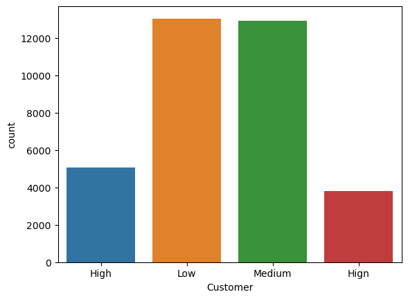

```python
# How many customers belong to each customer type
# .countplot(x = "Customer", data = df) where x == column with customer and data is our table


sns.countplot(x = "Customer", data = df);  #seaborn as sns #data visualisation
```

```python
## ABove showed incorrect data with "HIGN" and not HIGH
## i need to investigate
# filter df[customer] that is labelled 'Hign' and see the first three rows

df[df["Customer"] == "Hign"].head(3)
```

|  | Date | Customer | Sales Person | Customer_Age | Customer_Gender | State | Product_Category | Sub_Category | Payment Option | Quantity | ... | year | month | month_name | quarter | age_group | cost | revenue | profit | profit_label | profit_loss_label |
| --- | --- | --- | --- | --- | --- | --- | --- | --- | --- | --- | --- | --- | --- | --- | --- | --- | --- | --- | --- | --- | --- |
| 29770 | 2015-08-03 | Hign | Derick | 28 | F | Lagos | Phones | IPhone | Cash | 1.0 | ... | 2015.0 | 8.0 | August | 3.0 | 26 - 40 Young Adult | 2295.00 | 2136.00 | -159.0 | loss | loss |
| 29771 | 2015-08-04 | Hign | Derick | 28 | F | Lagos | Accessories | Keyboard | Cash | 2.0 | ... | 2015.0 | 8.0 | August | 3.0 | 26 - 40 Young Adult | 35.00 | 39.00 | 4.0 | profit | profit |
| 29772 | 2015-08-04 | Hign | Derick | 28 | F | Lagos | Accessories | Keyboard | Cash | 3.0 | ... | 2015.0 | 8.0 | August | 3.0 | 26 - 40 Young Adult | 50.01 | 56.01 | 6.0 | profit | profit |

3 rows × 22 columns

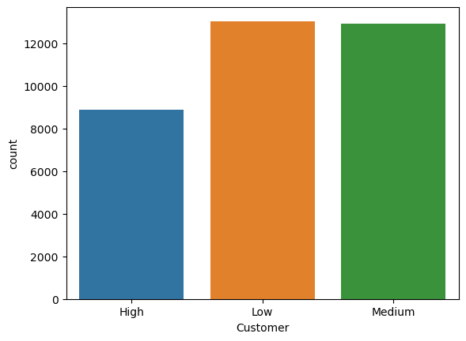

```python
# Correct the spellings of Hign
# df.loc is the date frame location where Hign is wtitten rather than High


df.loc[df["Customer"] == "Hign", "Customer"] = "High"

sns.countplot(x = "Customer", data = df); # to now visualise the data through counting of the column
```

## Majority of the transaction is by 'low' type customer, then 'medium' and 'high'

```python
## If i do not want to see the graph but i want the count of the values using [.value_counts]

df['Customer'].value_counts()
```

```
Low       13041
Medium    12926
High       8899
Name: Customer, dtype: int64
```

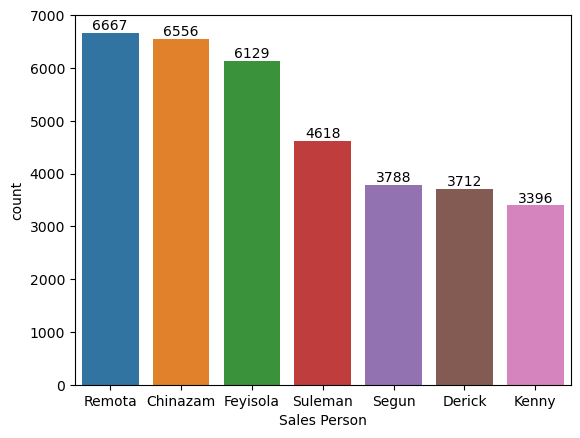

```python
# How many transactions by sales rep
# with a label on the chart
# order=df to arrange the chart
#ascending = false to go in descending order

sales_rep = sns.countplot(x = df['Sales Person'], order=df['Sales Person'].value_counts(ascending=False).index)

#to count the values in descending order on the chart
values = df['Sales Person'].value_counts(ascending=False).values

#to apply the label on the bar chart
sales_rep.bar_label(container=sales_rep.containers[0], labels=values);
```

# this shows that Remota was the sales rep with highest sales and kenny had the least sales

```python
df.columns
```

```
Index(['Date', 'Customer', 'Sales Person', 'Customer_Age', 'Customer_Gender',
       'State', 'Product_Category', 'Sub_Category', 'Payment Option',
       'Quantity', 'Unit_Cost', 'Unit_Price', 'year', 'month', 'month_name',
       'quarter', 'age_group', 'cost', 'revenue', 'profit', 'profit_label',
       'profit_loss_label'],
      dtype='object')
```

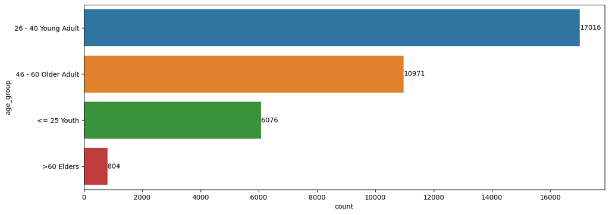

```python
# Tolat transactions by customer age group
# change the 'x' to 'y' for a change in position
# to allow your chart to have all the figures in it, simply write a code for figure size

plt.figure(figsize=(14,5)) # just to allow the numbers to be in the chart

age_group = sns.countplot(y = df['age_group'], order=df['age_group'].value_counts(ascending=False).index)

#to count the values in descending order on the chart
values = df['age_group'].value_counts(ascending=False).values

#to apply the label on the bar chart
age_group.bar_label(container=age_group.containers[0], labels=values);
```

## The age group "Adult" made the highest purchae and the least was by the "Elderly" group

```python
# Total transactions by customer gender

df.columns
```

```
Index(['Date', 'Customer', 'Sales Person', 'Customer_Age', 'Customer_Gender',
       'State', 'Product_Category', 'Sub_Category', 'Payment Option',
       'Quantity', 'Unit_Cost', 'Unit_Price', 'year', 'month', 'month_name',
       'quarter', 'age_group', 'cost', 'revenue', 'profit', 'profit_label',
       'profit_loss_label'],
      dtype='object')
```

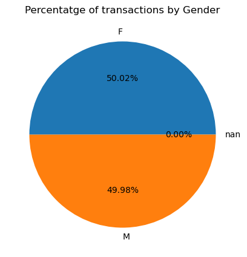

```python
# Total transactions by customer gender
# using a pie chart

fig,ax = plt.subplots(figsize=(5,5))

count = Counter(df["Customer_Gender"])

ax.pie(count.values(), labels=count.keys(), autopct=lambda p:f'{p:.2f}%')

ax.set_title("Percentatge of transactions by Gender")

plt.show();
```

## More females than males

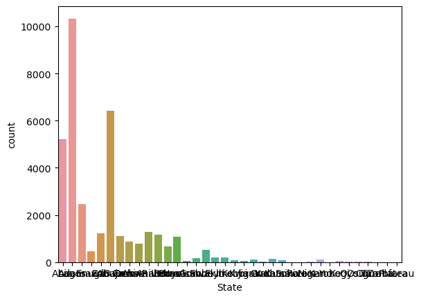

```python
# Total transactions by states/regions

sns.countplot(x = "State", data=df)
```

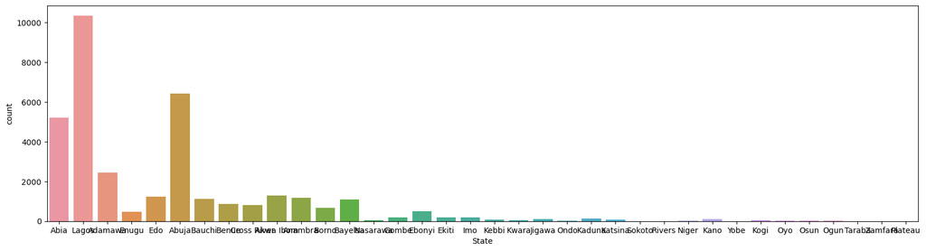

```python
# The above is kinda messy, let us do some maneuver
plt.figure(figsize = (20,5))
sns.countplot(x = "State", data=df);
```

```python
df["State"].value_counts()
```

```
Lagos          10332
Abuja           6421
Abia            5206
Adamawa         2446
Akwa Ibom       1287
Edo             1229
Anambra         1171
Bauchi          1112
Bayelsa         1092
Benue            869
Cross River      796
Borno            668
Ebonyi           509
Enugu            466
Ekiti            183
Imo              183
Gombe            181
Kaduna           132
Kano             100
Jigawa            96
Katsina           75
Kebbi             70
Kogi              61
Kwara             57
Nasarawa          42
Ondo              16
Ogun              16
Niger             13
Oyo               10
Osun               7
Yobe               6
Plateau            5
Sokoto             3
Rivers             3
Taraba             2
Zamfara            1
Name: State, dtype: int64
```

```python
df["State"].value_counts().head(10)
```

```
Lagos        10332
Abuja         6421
Abia          5206
Adamawa       2446
Akwa Ibom     1287
Edo           1229
Anambra       1171
Bauchi        1112
Bayelsa       1092
Benue          869
Name: State, dtype: int64
```

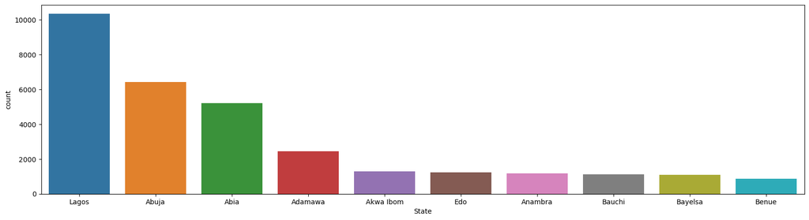

```python
## Still very poor
# Let us see the top 10 states
plt.figure(figsize = (20,5))

topten = df["State"].value_counts().head(10)

sns.countplot(x = "State", data=df, order=topten.index);
```

[output not shown]

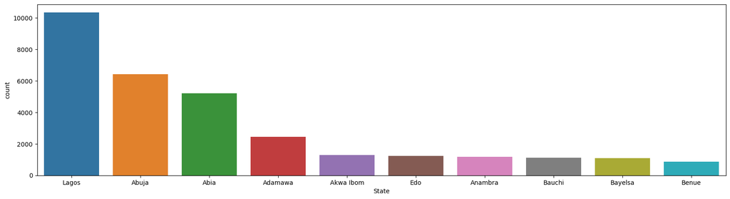

```python
plt.figure(figsize = (20,5)) # size

topten = df["State"].value_counts().head(10) # top ten value counts

sns.countplot(x = "State", data=df, order=topten.index); # visualisation of topten value count

print(topten) #to add the counts of the top ten states to the chart
```

```
Lagos        10332
Abuja         6421
Abia          5206
Adamawa       2446
Akwa Ibom     1287
Edo           1229
Anambra       1171
Bauchi        1112
Bayelsa       1092
Benue          869
Name: State, dtype: int64
```

[figure not shown]

```python
plt.figure(figsize = (20,5)) # size

topten = df["State"].value_counts().head(10) # top ten value counts

#assign state to the visualisation
State = sns.countplot(x = "State", data=df, order=topten.index); # visualisation of topten value count

#label state
State.bar_label(container=State.containers[0], labels=values);

print(topten) #to add the counts of the top ten states to the chart
```

## The top three states are Lagos, Abuja (FCT), Abia

```python
## WOrk on category, sub category, payment options, Month Name
```

```python
df.columns
```

```
Index(['Date', 'Customer', 'Sales Person', 'Customer_Age', 'Customer_Gender',
       'State', 'Product_Category', 'Sub_Category', 'Payment Option',
       'Quantity', 'Unit_Cost', 'Unit_Price'],
      dtype='object')
```

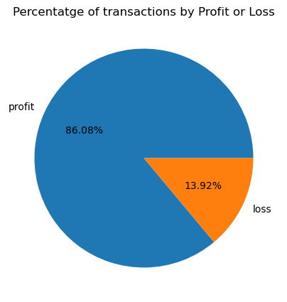

```python
## Profit of loss

fig,ax = plt.subplots(figsize=(5,5))

count = Counter(df["profit_label"])

ax.pie(count.values(), labels=count.keys(), autopct=lambda p:f'{p:.2f}%')

ax.set_title("Percentatge of transactions by Profit or Loss")

plt.show();
```

## More than 85% of the transactions were profit making and less than 14% were loses

## Numerical Visualisation

```python
df.columns
```

```
Index(['Date', 'Customer', 'Sales Person', 'Customer_Age', 'Customer_Gender',
       'State', 'Product_Category', 'Sub_Category', 'Payment Option',
       'Quantity', 'Unit_Cost', 'Unit_Price'],
      dtype='object')
```

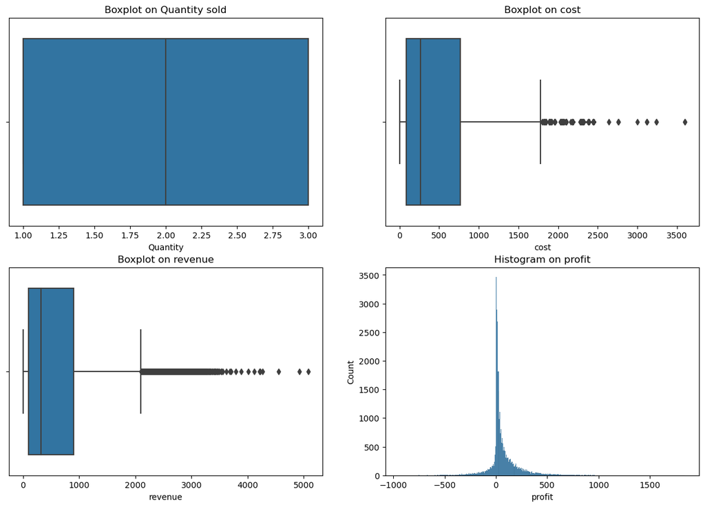

```python
# Quantity, Cost, Revenue, amd Profit - Subplot

fig, axs = plt.subplots(nrows= 2, ncols=2, figsize=(15,10))

#first box

# using a box plot for a numerical visulaisation
sns.boxplot(x="Quantity", data=df, ax=axs[0,0]) # the [0,0] means row 0 column 0 for the first plot. when plotting multiplr charts on a page

#add a title to the boxplot
axs[0,0].set_title("Boxplot on Quantity sold")


sns.boxplot(x="cost", data=df, ax=axs[0,1])
axs[0,1].set_title("Boxplot on cost")

sns.boxplot(x="revenue", data=df, ax=axs[1,0])
axs[1,0].set_title("Boxplot on revenue")

sns.histplot(x="profit", data=df, ax=axs[1,1])
axs[1,1].set_title("Histogram on profit");
```

## Shows that the Quantity was even with no outliers

## The cost price showed that we have outliers of cost price from qround 1700 and above and it is similar to revenue

## Now we go to Bivariate analysis

Bivariate analysis involves analysis between two variables

- focus on profit here

# Categorical data for bivariate analysis

```python
df.columns
```

```
Index(['Date', 'Customer', 'Sales Person', 'Customer_Age', 'Customer_Gender',
       'State', 'Product_Category', 'Sub_Category', 'Payment Option',
       'Quantity', 'Unit_Cost', 'Unit_Price'],
      dtype='object')
```

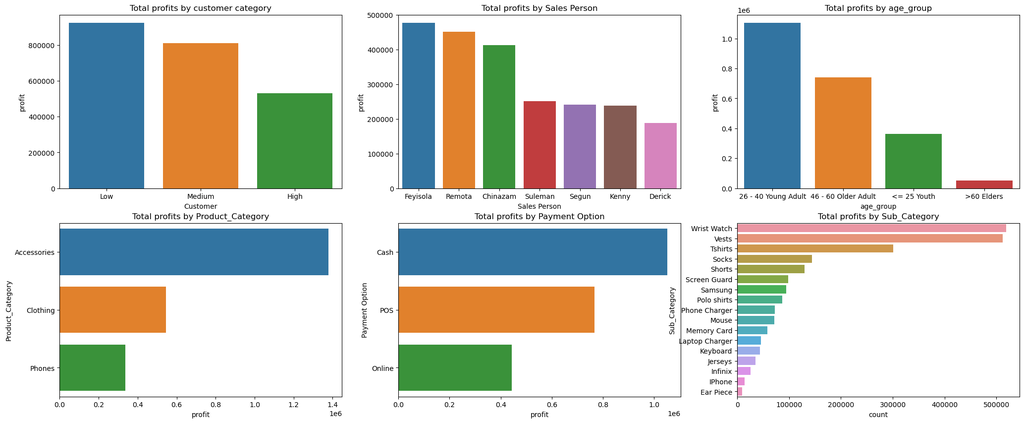

```python
# customer category and profit

fig, axs = plt.subplots(nrows= 2, ncols=3, figsize=(25,10)) # to create 6 plots

cus_pro = df.groupby("Customer")["profit"].sum().reset_index() #to add all profits in the customer category
cus_pro = cus_pro.sort_values(by='profit', ascending=False) # Sort by profit in descending order
sns.barplot(x='Customer', data = cus_pro, y='profit', ax=axs[0,0])
axs[0,0].set_title('Total profits by customer category');

sp_pro = df.groupby("Sales Person")["profit"].sum().reset_index()
sp_pro = sp_pro.sort_values(by='profit', ascending=False) # Sort by profit in descending order
sns.barplot(x='Sales Person', data = sp_pro, y='profit', ax=axs[0,1])
axs[0,1].set_title('Total profits by Sales Person');

ag_pro = df.groupby("age_group")["profit"].sum().reset_index()
ag_pro = ag_pro.sort_values(by='profit', ascending=False) # Sort by profit in descending order
sns.barplot(x='age_group', data = ag_pro, y='profit', ax=axs[0,2])
axs[0,2].set_title('Total profits by age_group');

pc_pro = df.groupby("Product_Category")["profit"].sum().reset_index()
pc_pro = pc_pro.sort_values(by='profit', ascending=False) # Sort by profit in descending order
sns.barplot(y='Product_Category', data = pc_pro, x='profit', ax=axs[1,0])
axs[1,0].set_title('Total profits by Product_Category');

po_pro = df.groupby("Payment Option")["profit"].sum().reset_index()
po_pro = po_pro.sort_values(by='profit', ascending=False) # Sort by profit in descending order
sns.barplot(y='Payment Option', data = po_pro, x='profit', ax=axs[1,1])
axs[1,1].set_title('Total profits by Payment Option');

sc_pro = df.groupby("Sub_Category")["profit"].sum().reset_index()
sc_pro = sc_pro.sort_values(by='profit', ascending=False)  # Sort by profit in descending order
sns.barplot(y='Sub_Category', data=sc_pro, x='profit', ax=axs[1,2])
axs[1,2].set_title('Total profits by Sub_Category')
sc_pro = sns.countplot(y=df['Sub_Category'], order=df['Sub_Category'].value_counts().index.sort_values(ascending=False));
```

# Total Profit was more with the customer labelled "low" followed by medium

# Feyisola, Remota, Chinazam were the three highest sales person who contributed significantly to total profits